# L2P2: Mais distribuições, sumários e correlação

Matheus Gomes Maia

```r
library(tidyverse)
library(here)
library(ggExtra)
library(cowplot)

theme_set(theme_bw())
```

```r
clima_tudo = read_csv(
    here("data/tempo-jp-cg-pt.csv"),
    col_types = cols(
        .default = col_double(),
        cidade = col_character(),
        semana = col_date(format = ""),
        ano = col_integer(),
        mes = col_integer()
    )
)

clima10 = clima_tudo %>%
    filter(ano <= 2019, ano >= 2010, !is.na(temp_max))
```

Na resposta das perguntas abaixo queremos dar ênfase à análise de distribuições e usos de sumários, então não use nenhuma visualização de linha do tempo. Também lembre que a resposta a qualquer tarefa de análise é uma combinação de visualização de dados, sumários estatísticos e texto que interpreta ambos. Ao acabar cada resposta, confira se você tem esses 3 elementos. Você descreveu as distribuições envolvidas? Comentou em formato e pontos extremos? Está comentando as diferenças que observa? Elas são grandes? Pequenas?

1. Descreva a relação entre temperatura média, umidade e chuvas por semana nas 3 cidades, analisando essas características duas a duas. Além de descrever as relações, comparando-as entre cidades e para uma mesma cidade, comente o que se deve esperar em geral em uma semana mais fria nas 3 cidades.
2. Escolha duas das cidades e compare a temperatura e as chuvas das duas nos últimos doze meses. Quantifique e comente a diferença entre a temperatura nas duas cidades. Lembre que você tem medições pareadas das variáveis para as duas cidades, e lembre de olhar a distribuição além de qualquer sumário que você escolher.
3. Escolha uma das cidades e compare a temperatura e as chuvas das semanas de 2021 com a temperatura e chuva das semanas dos últimos 10 anos. Esse ano tem sido um ano muito quente? Com muita chuva? Compare as distribuições.

## Descreva a relação entre temperatura média, umidade e chuvas por semana nas 3 cidades, analisando essas características duas a duas.

```r
clima10 = clima_tudo %>%
    filter(ano <= 2019, ano >= 2010, !is.na(temp_max)) %>%
    group_by(cidade, semana, ano) %>%
    summarise(temp_media = mean(temp_media),
              umidade = mean(umidade),
              chuva = mean(chuva),
              .groups = "drop")
semanas_frias = clima_tudo %>%
    filter(ano <= 2019, ano >= 2010, !is.na(temp_max)) %>% group_by(cidade) %>% top_n(-1, temp_media)
```

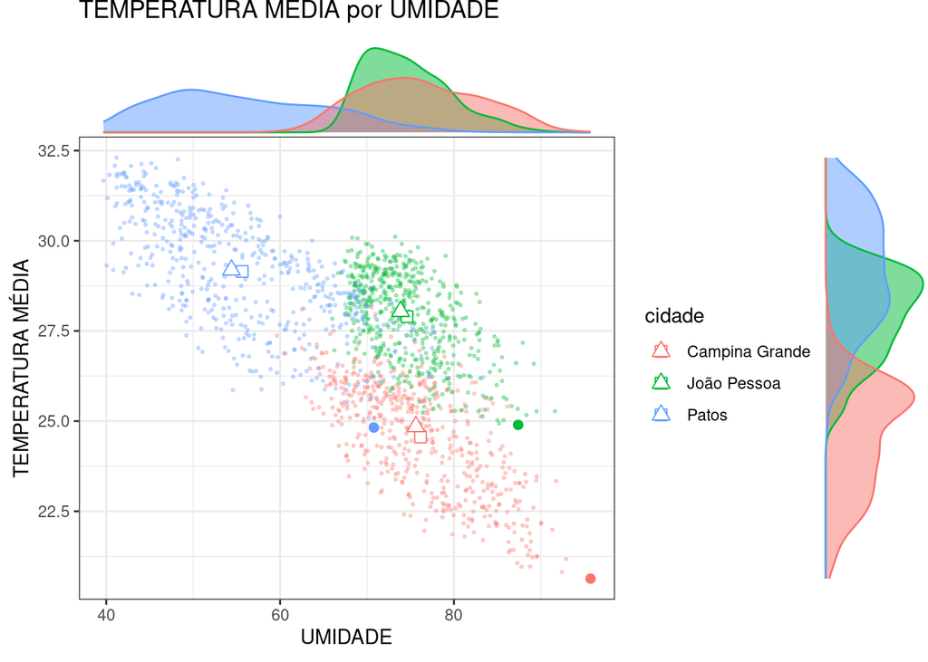

```r
sumario = clima10 %>%
    group_by(cidade) %>%
    summarise(media_temp = mean(temp_media),
              media_umidade = mean(umidade),
              mediana_temp = median(temp_media),
              mediana_umidade = median(umidade),
              .groups = "drop")

g <- ggplot(clima10 , aes(x = umidade, y = temp_media, color = cidade)) +
    geom_point( alpha = .3, size=.5) +
    geom_point(data = semanas_frias, alpha = 1, size=2) +
    geom_point(data = sumario, mapping = aes(x = media_umidade, y=media_temp), size=3, pch=22, fill= "white")+
    geom_point(data = sumario, mapping = aes(x = mediana_umidade, y=mediana_temp), size=3,pch=24, fill="white")+
    ggtitle("TEMPERATURA MÉDIA por UMIDADE ")+
    labs(
         x = "UMIDADE",
         y = "TEMPERATURA MÉDIA"
    )
ggMarginal(g, groupColour=TRUE, type = "density", groupFill=TRUE, alpha=.5)
```

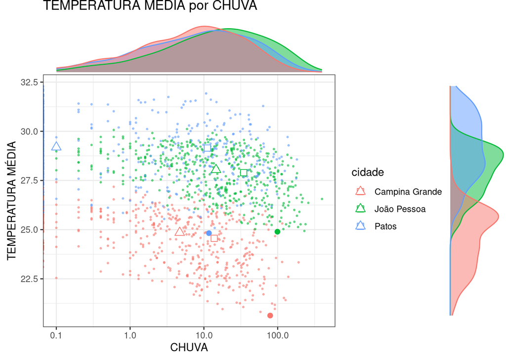

```r
sumario = clima10 %>%
    group_by(cidade) %>%
    summarise(media_temp = mean(temp_media),
              media_chuva = mean(chuva),
              mediana_temp = median(temp_media),
              mediana_chuva = median(chuva),
              .groups = "drop")

g <- ggplot(clima10 , aes(x = chuva, y = temp_media, color = cidade)) +
    geom_point( alpha = .5, size = .5) +
    geom_point(data = semanas_frias, alpha = 1, size=2) +
    geom_point(data = sumario, mapping = aes(x = media_chuva, y=media_temp), size=3, pch=22, fill= "white")+
    geom_point(data = sumario, mapping = aes(x = mediana_chuva, y=mediana_temp), size=3,pch=24, fill="white")+
    ggtitle("TEMPERATURA MÉDIA por CHUVA ")+
    scale_x_log10()+
    labs(
         x = "CHUVA",
         y = "TEMPERATURA MÉDIA"
    )
ggMarginal(g, groupColour=TRUE, type = "density", groupFill=TRUE, alpha=.5)
```

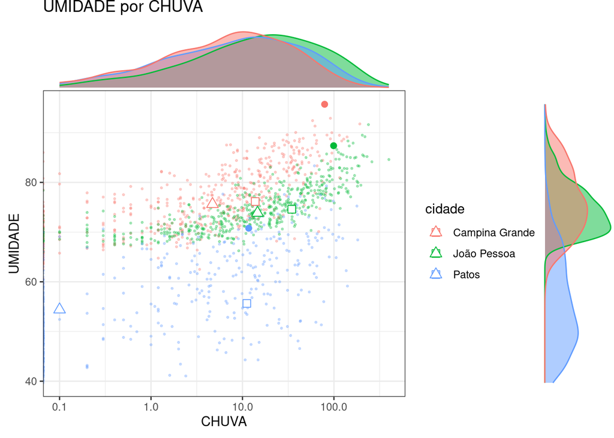

```r
sumario = clima10 %>%
    group_by(cidade) %>%
    summarise(media_umidade = mean(umidade),
              media_chuva = mean(chuva),
              mediana_umidade = median(umidade),
              mediana_chuva = median(chuva),
              .groups = "drop")

g <- ggplot(clima10 , aes(x = chuva, y = umidade, color = cidade)) +
    geom_point( alpha = .3, size = .5) +
    geom_point(data = semanas_frias, alpha = 1, size=2) +
    geom_point(data = sumario, mapping = aes(x = media_chuva, y=media_umidade), size=3, pch = 22, fill = "white")+
    geom_point(data = sumario, mapping = aes(x = mediana_chuva, y=mediana_umidade), size=3,pch = 24, fill = "white")+
    ggtitle("UMIDADE por CHUVA ")+
    scale_x_log10()+
    labs(
         x = "CHUVA",
         y = "UMIDADE"
    )
ggMarginal(g, groupColour=TRUE, type = "density", groupFill=TRUE, alpha=.5)
```

```r
sumario = clima10 %>%
    group_by(cidade) %>%
    summarise(media_umidade = mean(umidade),
              mediana_umidade = median(umidade),
              media_chuva = mean(chuva),
              mediana_chuva = median(chuva),
              media_tempo = mean(temp_media),
              mediana_tempo = median(temp_media),
              corr_tempo_umidade = cor(temp_media, umidade),
              corr_tempo_chuva = cor(temp_media, chuva),
              corr_umidade_chuva = cor(umidade, chuva),
              .groups = "drop")

cidades = sumario$cidade
t_sumario = as.data.frame(t(sumario[,-1]))
colnames(t_sumario) <- cidades
t_sumario
```

|  | Campina Grande | João Pessoa | Patos |
| --- | --- | --- | --- |
| media_umidade | 76.1515496 | 74.5896690 | 55.6468035 |
| mediana_umidade | 75.6190476 | 73.8571429 | 54.4047619 |
| media_chuva | 13.7830116 | 34.5973180 | 11.1557471 |
| mediana_chuva | 4.7000000 | 14.6000000 | 0.1000000 |
| media_tempo | 24.5598497 | 27.8975700 | 29.1477655 |
| mediana_tempo | 24.8500000 | 28.0428571 | 29.1902381 |
| corr_tempo_umidade | -0.7107841 | -0.5508765 | -0.6852173 |
| corr_tempo_chuva | -0.4055062 | -0.4498177 | -0.1727192 |
| corr_umidade_chuva | 0.6169479 | 0.7639434 | 0.4911236 |

Nos gráficos de pares o quadrado representa a média e o triângulo a mediana. O ponto de maior tamanho apresenta os valores da semana mais fria registrada nos dados.

A partir dos gŕaficos de pares e dos sumários apresentados podemos entender as distribuicões e correlacões presentes nos dados.

É interessante observar que a chuva tem menos relacão com o temperatura na cidade de Patos do que nas outras cidades, ou seja, quando chove em patos a temperatura não tende e cair como cai nas outras cidades.

A umidade e a chuva apresentam uma correlacão positiva em todas as cidades, sendo moderada em Patos e forte nas demais cidades. Ou seja, em Patos, a chuva não está fortemente correlacionada com queda de temperatura e aumento de umidade como nas outras cidades.

Uma semana fria em João Pessoa e Campina Grande, tende a ser uma semana chuvosa e com alta umidade. Já em Patos as semanas mais chuvosas não são, necessáriamente, as semanas mais frias. Essa tendência se confirma no extremo da semana mais fria registrada. A semana mais fria regristrada nas cidades Campina Grande e João Pessoa foi uma semana de muita chuva. Já em Patos a semana mais fria não choveu de maneira especial.

## Escolha duas das cidades e compare a temperatura e as chuvas das duas nos últimos doze meses.

```r
jpacg = clima_tudo %>%
    filter(cidade != "Patos", !is.na(temp_max), mes < 4 & ano == 2021 | mes > 3 & ano == 2020)

jpacg_mes  = jpacg %>%
    group_by(cidade, mes) %>%
    summarise(temp_media = mean(temp_media),
    chuva = mean(chuva),
    semana = first(semana),
    .groups = "drop")
```

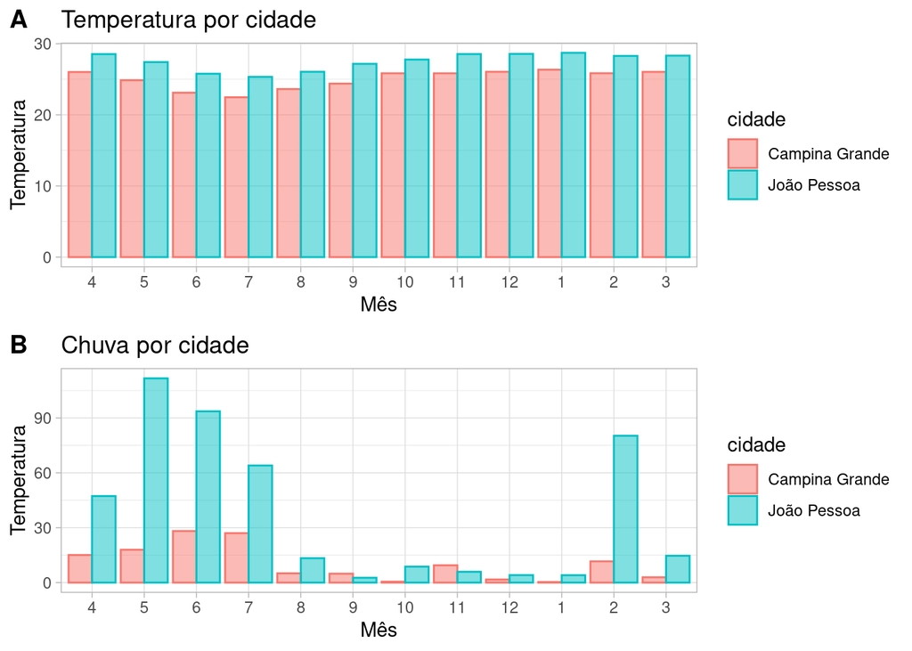

```r
iris1 <- ggplot(jpacg_mes, aes(x = reorder(mes, semana), y=temp_media, color = cidade, fill=cidade)) +
  geom_bar(stat="identity",position = "dodge", alpha=0.5) +
  theme_light() +
    labs(
         title= "Temperatura por cidade",
         x = "Mês",
         y = "Temperatura"
    )

iris2 <- ggplot(jpacg_mes, aes(x = reorder(mes, semana), y=chuva, color = cidade, fill=cidade)) +
  geom_bar(stat="identity",position = "dodge", alpha=0.5) +
  theme_light() +
    labs(
         title= "Chuva por cidade",
         x = "Mês",
         y = "Temperatura"
    )

plot_grid(iris1, iris2, labels = "AUTO", ncol = 1)
```

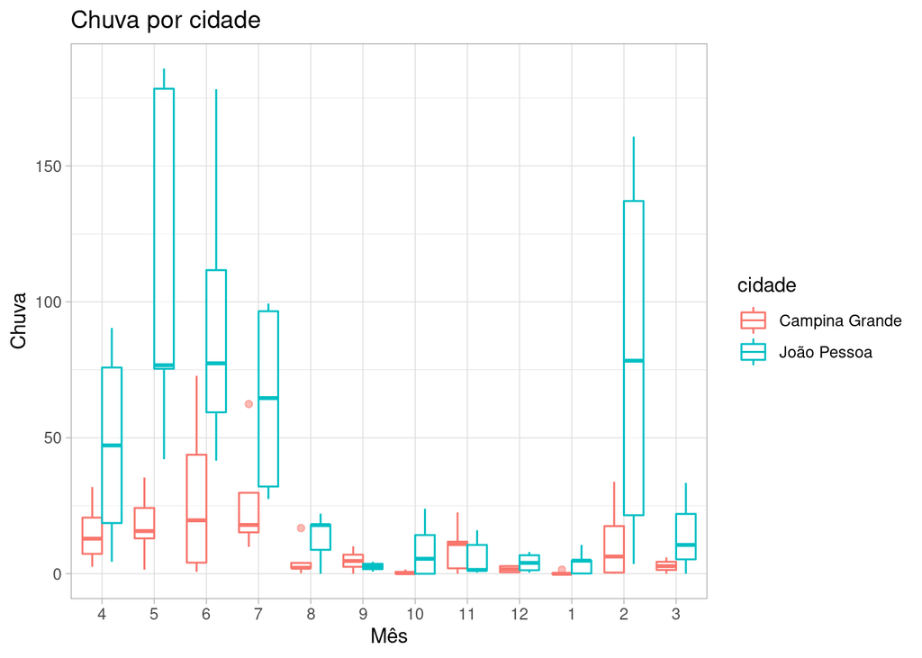

```r
ggplot(jpacg, aes(x = reorder(mes, semana), y=chuva, color = cidade)) +
  geom_boxplot(position = "dodge", alpha=0.5) +
  theme_light() +
    labs(
         title= "Chuva por cidade",
         x = "Mês",
         y = "Chuva"
    )
```

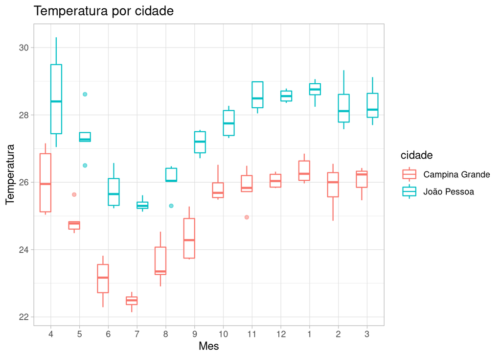

```r
ggplot(jpacg, aes(x = reorder(mes, semana), y=temp_media, color = cidade)) +
  geom_boxplot(position = "dodge", alpha=0.5) +
  theme_light() +
    labs(
         title= "Temperatura por cidade",
         x = "Mes",
         y = "Temperatura"
    )
```

Nos ultimos doze meses em João Pessoa choveu e fez mais calor do que em Campina Grande. Se o comportamento do último ano se repetir, em João Pessoa vai chover muito nos próximos meses. A amplitude de milimetros de chuva em João Pessoa é grande, ou seja, dentro de um mesmo mês as semanas se diferem muito na quantidade de chuva. No intervalo de tempo estudado, Campina Grande é sempre mais fria nas médias das semanas do que em João Pessoa.

## Escolha uma das cidades e compare a temperatura e as chuvas das semanas de 2021 com a temperatura e chuva das semanas dos últimos 10 anos

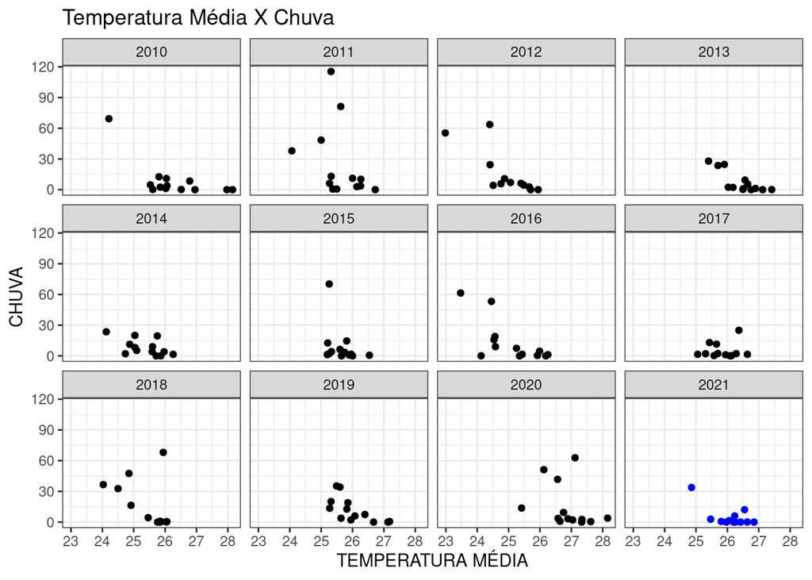

```r
cg2021 = clima_tudo %>%
    filter(cidade == "Campina Grande", ano == 2021, mes < 4, !is.na(temp_max))

cga2021 = clima_tudo %>%
    filter(cidade == "Campina Grande", ano < 2021, mes < 4, !is.na(temp_max))

ggplot(cga2021, aes(x  = temp_media, y = chuva)) +
    geom_point(data= cga2021) +
    geom_point(data= cg2021, aes(x  = temp_media, y = chuva), color = "blue") +
    facet_wrap(~ano) +
    labs(
        title = "Temperatura Média X Chuva",
        x = "TEMPERATURA MÉDIA",
        y = "CHUVA"
)
```